# [TYTUŁ ROBOCZY] Different patterns of diversity, richness and community composition of predators, parasitoids and herbivorous Aculaeta during succession of sand quarries.

## Wyniki

### 1. Wzorce w charakterystykach zgrupowań

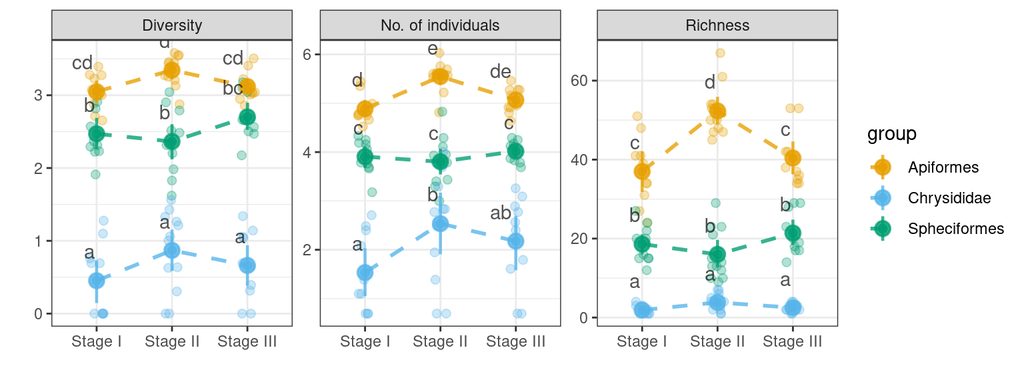

**Figure 1. Różnorodność,liczebność i bogactwo gatunkowe trzech grup Aculaeta w zależności od trzech wyróżnionych stadiów sukcesji żwirowni. Przedstawiono średnie oraz 95% CI typu bootstrap. Liczba osobników została poddana transformacji logarytmicznej w celu lepszej wizualizacji różnic omiędzy grupami. Punkty oznaczją wartości empiryczne. Litery łacińskie oznaczają wyniki testu post-hoc z poprawką Tukeya dla $\alpha$ = 0.05.**

## 2. Struktura zgrupowań

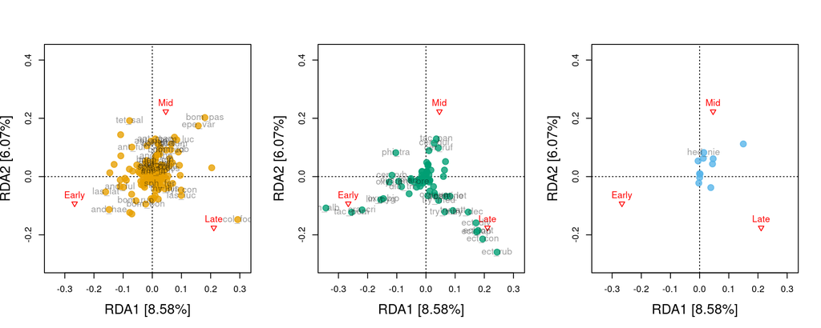

**Figure 2. Wykres ordynacji RDA dla stadium sukcesji jako dyskretnej zmiennej objaśniającej. W celu lepszej wizualizacji punkty zostały naniesione osobno. Na wykresie ordynacji przedstawiono gatunki które najsilniej odpowiadały nia czynik jakim są stadia sukcesji. Model tłumaczy 14.6544593% zmienności zgrupowań.**

**Tab X. Lista gatunków których liczebność istotnie zmienia się w sposób wyznaczony przez stadia sukcesji w modelu RDA**

|  | RDA1 | RDA2 | Group |
| --- | --- | --- | --- |
| and_ful | 0.233 | 0.252 | Apiformes |
| and_hae | 0.213 | 0.318 | Apiformes |
| and_mil | 0.006 | 0.172 | Apiformes |
| and_nig | 0.030 | 0.078 | Apiformes |
| and_tho | 0.010 | 0.276 | Apiformes |
| and_wil | 0.006 | 0.167 | Apiformes |
| ant_lit | 0.002 | 0.054 | Apiformes |
| ant_man | 0.002 | 0.226 | Apiformes |
| ant_pun | 0.000 | 0.143 | Apiformes |
| ant_fur | 0.086 | 0.237 | Apiformes |
| bom_boh | 0.006 | 0.094 | Apiformes |
| bom_luc | 0.081 | 0.234 | Apiformes |
| bom_pas | 0.125 | 0.257 | Apiformes |
| bom_rud | 0.024 | 0.099 | Apiformes |
| bom_rup | 0.063 | 0.178 | Apiformes |
| bom_sch | 0.006 | 0.166 | Apiformes |
| col_qua | 0.007 | 0.202 | Apiformes |
| col_fod | 0.250 | 0.303 | Apiformes |
| epe_var | 0.176 | 0.356 | Apiformes |
| euc_lon | 0.026 | 0.059 | Apiformes |
| hal_tum | 0.047 | 0.164 | Apiformes |
| hyl_con | 0.222 | 0.263 | Apiformes |
| las_cos | 0.060 | 0.081 | Apiformes |
| las_lat | 0.142 | 0.155 | Apiformes |
| las_luc | 0.142 | 0.193 | Apiformes |
| meg_cir | 0.005 | 0.138 | Apiformes |
| nom_rob | 0.051 | 0.142 | Apiformes |
| sph_cra | 0.004 | 0.110 | Apiformes |
| sph_fer | 0.080 | 0.147 | Apiformes |
| sph_pun | 0.010 | 0.288 | Apiformes |
| tet_sal | 0.022 | 0.137 | Apiformes |
| thy_his | 0.111 | 0.203 | Apiformes |
| cer_qui | 0.008 | 0.129 | Spheciformes |
| cer_ruf | 0.036 | 0.199 | Spheciformes |
| cer_ryb | 0.210 | 0.210 | Spheciformes |
| cra_cri | 0.455 | 0.560 | Spheciformes |
| dio_tri | 0.260 | 0.297 | Spheciformes |
| ect_con | 0.336 | 0.680 | Spheciformes |
| ect_ont | 0.258 | 0.492 | Spheciformes |
| ect_div | 0.328 | 0.564 | Spheciformes |
| ect_lap | 0.217 | 0.437 | Spheciformes |
| ect_rub | 0.369 | 0.720 | Spheciformes |
| ent_bre | 0.197 | 0.225 | Spheciformes |
| lin_alb | 0.388 | 0.420 | Spheciformes |
| lin_pyg | 0.387 | 0.472 | Spheciformes |
| nys_mac | 0.140 | 0.143 | Spheciformes |
| oxy_bip | 0.436 | 0.535 | Spheciformes |
| oxy_tri | 0.321 | 0.328 | Spheciformes |
| oxy_var | 0.027 | 0.123 | Spheciformes |
| pem_ino | 0.199 | 0.362 | Spheciformes |
| pem_let | 0.267 | 0.418 | Spheciformes |
| phi_tra | 0.083 | 0.127 | Spheciformes |
| tac_pan | 0.020 | 0.247 | Spheciformes |
| tac_pom | 0.471 | 0.562 | Spheciformes |
| try_att | 0.170 | 0.399 | Spheciformes |
| try_dec | 0.296 | 0.472 | Spheciformes |
| try_med | 0.019 | 0.076 | Spheciformes |
| try_min | 0.071 | 0.283 | Spheciformes |
| hed_nie | 0.012 | 0.350 | Chrysididae |